# GitHub

From Wikipedia, the free encyclopedia

Not to be confused with Git or GitLab.

GitHub, Inc.

GitHub Logo

[Type of business](https://en.wikipedia.org/wiki/Types_of_business_entity)

Subsidiary

Type of site

Collaborative [version control](https://en.wikipedia.org/wiki/Version_control)

Available in

English

Founded

February 8, 2008; 14 years ago (as Logical Awesome LLC)

Headquarters

San Francisco, California, U.S.

Area served

Worldwide

[Founder(s)](https://en.wikipedia.org/wiki/Organizational_founder)

- [Tom Preston-Werner](https://en.wikipedia.org/wiki/Tom_Preston-Werner)
- [Chris Wanstrath](https://en.wikipedia.org/wiki/Chris_Wanstrath)
- [P. J. Hyett](https://en.wikipedia.org/wiki/P._J._Hyett)
- Scott Chacon

CEO

Thomas Dohmke

Key people

- Mike Taylor (CFO)
- Erica Brescia (COO)

Industry

Collaborative [version control](https://en.wikipedia.org/wiki/Version_control) (GitHub)  
[Blog host](https://en.wikipedia.org/wiki/Web_hosting_service) (GitHub Pages)  
[Package repository](https://en.wikipedia.org/wiki/Package_repository) (NPM)

Revenue

$200-300 million (2018)<sup>[1]</sup>

Employees

2500<sup>[2]</sup>

[Parent](https://en.wikipedia.org/wiki/Holding_company)

Microsoft

URL

[github.com](https://github.com/)

Registration

Optional (required for creating and joining repositories, and browsing all repositories.)

[Users](https://en.wikipedia.org/wiki/Registered_user)

83 million (as of June 2022)

Launched

April 10, 2008; 14 years ago

Current status

Active

Written in

Ruby  
JavaScript  
Go  
C<sup>[3]</sup>

**GitHub, Inc.** is a provider of [Internet hosting](https://en.wikipedia.org/wiki/Internet_hosting_service) for [software development](https://en.wikipedia.org/wiki/Software_development) and [version control](https://en.wikipedia.org/wiki/Version_control) using Git. It offers the [distributed version control](https://en.wikipedia.org/wiki/Distributed_version_control) and [source code management](https://en.wikipedia.org/wiki/Source_code_management) (SCM) functionality of Git, plus its own features. It provides [access control](https://en.wikipedia.org/wiki/Access_control) and several collaboration features such as [bug tracking](https://en.wikipedia.org/wiki/Bug_tracking_system), feature requests, [task management](https://en.wikipedia.org/wiki/Task_management), [continuous integration](https://en.wikipedia.org/wiki/Continuous_integration), and [wikis](https://en.wikipedia.org/wiki/Wiki) for every project.<sup>[4]</sup> Headquartered in California, it has been a subsidiary of Microsoft since 2018.<sup>[5]</sup>

It is commonly used to host [open-source](https://en.wikipedia.org/wiki/Open-source) projects.<sup>[6]</sup> As of June 2022, GitHub reports having over 83 million developers<sup>[7]</sup> and more than 200 million repositories<sup>[8]</sup> (including at least 28 million public repositories).<sup>[9]</sup> It is the largest [source code](https://en.wikipedia.org/wiki/Source_code) host as of November 2021.

## History[[edit](https://en.wikipedia.org/w/index.php?title=GitHub&action=edit&section=1)]

[figure not shown]

GitHub at AWS Summit

### GitHub.com[[edit](https://en.wikipedia.org/w/index.php?title=GitHub&action=edit&section=2)]

Development of the GitHub.com platform began on October 19, 2007.<sup>[10]</sup><sup>[11]</sup><sup>[12]</sup> The site was launched in April 2008 by [Tom Preston-Werner](https://en.wikipedia.org/wiki/Tom_Preston-Werner), [Chris Wanstrath](https://en.wikipedia.org/wiki/Chris_Wanstrath), [P. J. Hyett](https://en.wikipedia.org/wiki/P._J._Hyett) and [Scott Chacon](https://en.wikipedia.org/w/index.php?title=Scott_Chacon&action=edit&redlink=1) after it had been made available for a few months prior as a beta release.<sup>[13]</sup> GitHub has an annual [keynote](https://en.wikipedia.org/wiki/Keynote) called GitHub Universe.<sup>[14]</sup>

### Organizational structure[[edit](https://en.wikipedia.org/w/index.php?title=GitHub&action=edit&section=3)]

GitHub, Inc. was originally a [flat organization](https://en.wikipedia.org/wiki/Flat_organization) with no middle managers; in other words, "everyone is a manager" (self-management).<sup>[15]</sup> Employees could choose to work on projects that interested them ([open allocation](https://en.wikipedia.org/wiki/Open_allocation)), but salaries were set by the chief executive.<sup>[16]</sup><sup>[*[needs update](https://en.wikipedia.org/wiki/Wikipedia:Manual_of_Style/Dates_and_numbers#Chronological_items)*]</sup>

In 2014, GitHub, Inc. introduced a layer of [middle management](https://en.wikipedia.org/wiki/Middle_management) amid harassment claims made against senior management. [Tom Preston-Werner](https://en.wikipedia.org/wiki/Tom_Preston-Werner) resigned as CEO amid the scandal.<sup>[17]</sup>

### Finance[[edit](https://en.wikipedia.org/w/index.php?title=GitHub&action=edit&section=4)]

On February 24, 2009, GitHub announced that within the first year of being online, GitHub had accumulated over 46,000 public repositories, 17,000 of which were formed in the previous month. At that time, about 6,200 repositories had been forked at least once and 4,600 had been merged.

That same year, the site was used by over 100,000 users, according to GitHub, and had grown to host 90,000 unique public repositories, 12,000 having been forked at least once, for a total of 135,000 repositories.<sup>[21]</sup>

In 2010, GitHub was hosting 1 million repositories.<sup>[22]</sup> A year later, this number doubled.<sup>[23]</sup> ReadWriteWeb reported that GitHub had surpassed SourceForge and [Google Code](https://en.wikipedia.org/wiki/Google_Code) in total number of commits for the period of January to May 2011.<sup>[24]</sup> On January 16, 2013, GitHub passed the 3 million users mark and was then hosting more than 5 million repositories.<sup>[25]</sup> By the end of the year, the number of repositories was twice as great, reaching 10 million repositories.<sup>[26]</sup>

In 2012, GitHub raised $100 million in funding from [Andreessen Horowitz](https://en.wikipedia.org/wiki/Andreessen_Horowitz) with a $750 million valuation.<sup>[27]</sup> On July 29, 2015, GitHub stated it had raised $250 million in funding in a round led by [Sequoia Capital](https://en.wikipedia.org/wiki/Sequoia_Capital). Other investors of that round included Andreessen Horowitz, Thrive Capital, and IVP (Institutional Venture Partners).<sup>[28]</sup> The round valued the company at approximately $2 billion.<sup>[29]</sup>

In 2015, GitHub opened an office in Japan, its first outside of the U.S.<sup>[30]</sup> In 2016, GitHub was ranked No. 14 on the *Forbes* Cloud 100 list.<sup>[31]</sup> It was not featured on the 2018, 2019, and 2020 lists.<sup>[32]</sup>

On February 28, 2018, GitHub fell victim to the third-largest [distributed denial-of-service](https://en.wikipedia.org/wiki/Distributed_denial-of-service) (DDoS) attack in history, with incoming traffic reaching a peak of about 1.35 terabits per second.<sup>[33]</sup>

On June 19, 2018, GitHub expanded its GitHub Education by offering free education bundles to all schools.<sup>[34]</sup><sup>[35]</sup>

### Acquisition by Microsoft[[edit](https://en.wikipedia.org/w/index.php?title=GitHub&action=edit&section=5)]

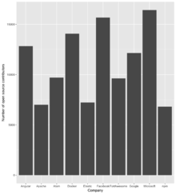

Microsoft on top of list of the ten organizations with the most open-source contributors on GitHub in 2016<sup>[36]</sup>

From 2012, Microsoft became a significant user of GitHub, using it to host open-source projects and development tools such as [.NET Core](https://en.wikipedia.org/wiki/.NET), Chakra Core, MSBuild, PowerShell, PowerToys, [Visual Studio Code](https://en.wikipedia.org/wiki/Visual_Studio_Code), [Windows Calculator](https://en.wikipedia.org/wiki/Windows_Calculator), [Windows Terminal](https://en.wikipedia.org/wiki/Windows_Terminal) and the bulk of its product documentation (now to be found on [Microsoft Docs](https://en.wikipedia.org/wiki/Microsoft_Docs)).<sup>[37]</sup><sup>[38]</sup>

On June 4, 2018, Microsoft announced its intent to acquire GitHub for US$7.5 billion. The deal closed on October 26, 2018.<sup>[39]</sup> GitHub continued to operate independently as a community, platform and business.<sup>[40]</sup> Under Microsoft, the service was led by Xamarin's [Nat Friedman](https://en.wikipedia.org/wiki/Nat_Friedman), reporting to [Scott Guthrie](https://en.wikipedia.org/wiki/Scott_Guthrie), executive vice president of Microsoft Cloud and AI. GitHub's CEO, Chris Wanstrath, was retained as a "technical fellow," also reporting to Guthrie. Nat Friedman resigned November 3, 2021; replaced by Thomas Domke. <sup>[41]</sup>

There have been concerns from developers Kyle Simpson, JavaScript trainer and author, and Rafael Laguna, CEO at Open-Xchange over Microsoft's purchase, citing uneasiness over Microsoft's handling of previous acquisitions, such as [Nokia's mobile business](https://en.wikipedia.org/wiki/Microsoft_Mobile) and Skype.<sup>[42]</sup><sup>[43]</sup>

This acquisition was in line with Microsoft's business strategy under CEO [Satya Nadella](https://en.wikipedia.org/wiki/Satya_Nadella), which has seen a larger focus on [cloud computing](https://en.wikipedia.org/wiki/Cloud_computing) services, alongside the development of and contributions to open-source software.<sup>[5]</sup><sup>[38]</sup><sup>[44]</sup> *[Harvard Business Review](https://en.wikipedia.org/wiki/Harvard_Business_Review)* argued that Microsoft was intending to acquire GitHub to get access to its user base, so it can be used as a [loss leader](https://en.wikipedia.org/wiki/Loss_leader) to encourage the use of its other development products and services.<sup>[45]</sup>

Concerns over the sale bolstered interest in competitors: Bitbucket (owned by Atlassian), GitLab and SourceForge (owned by BIZX, LLC) reported that they had seen spikes in new users intending to migrate projects from GitHub to their respective services.<sup>[46]</sup><sup>[47]</sup><sup>[48]</sup><sup>[49]</sup><sup>[50]</sup>

In September 2019, GitHub acquired Semmle, a code analysis tool.<sup>[51]</sup> In February 2020, GitHub launched in India under the name GitHub India Private Limited.<sup>[52]</sup> In March 2020, GitHub announced that they were acquiring npm, a JavaScript packaging vendor, for an undisclosed sum of money.<sup>[53]</sup> The deal was closed on 15 April 2020.<sup>[54]</sup>

In early July 2020, the GitHub Archive Program was established, to archive its open-source code in perpetuity.<sup>[55]</sup>

### Mascot[[edit](https://en.wikipedia.org/w/index.php?title=GitHub&action=edit&section=6)]

GitHub's [mascot](https://en.wikipedia.org/wiki/Mascot) is an [anthropomorphized](https://en.wikipedia.org/wiki/Anthropomorphized) "octocat" with five [octopus-like arms](https://en.wikipedia.org/wiki/Cephalopod_limb).<sup>[56]</sup><sup>[57]</sup> The character was created by graphic designer [Simon Oxley](https://en.wikipedia.org/wiki/Simon_Oxley) as [clip art](https://en.wikipedia.org/wiki/Clip_art) to sell on [iStock](https://en.wikipedia.org/wiki/IStock),<sup>[58]</sup> a website that enables designers to market [royalty-free](https://en.wikipedia.org/wiki/Royalty-free) [digital images](https://en.wikipedia.org/wiki/Digital_image). GitHub became interested in Oxley's work after Twitter selected a bird that he designed for their own logo.<sup>[59]</sup> The illustration GitHub chose was a character that Oxley had named Octopuss.<sup>[58]</sup> Since GitHub wanted Octopuss for their logo (a use that the iStock license disallows), they negotiated with Oxley to buy exclusive rights to the image.<sup>[58]</sup>

GitHub renamed Octopuss to Octocat,<sup>[58]</sup> and trademarked the character along with the new name.<sup>[56]</sup> Later, GitHub hired illustrator Cameron McEfee to adapt Octocat for different purposes on the website and promotional materials; McEfee and various GitHub users have since created hundreds of variations of the character, which are available on [The Octodex](https://octodex.github.com/).<sup>[60]</sup><sup>[61]</sup>

## Services[[edit](https://en.wikipedia.org/w/index.php?title=GitHub&action=edit&section=7)]

Projects on GitHub.com can be accessed and managed using the standard Git command-line interface; all standard Git commands work with it. GitHub.com also allows users to browse public repositories on the site. Multiple desktop clients and Git plugins are also available. The site provides [social networking](https://en.wikipedia.org/wiki/Social_networking)-like functions such as feeds, followers, wikis (using [wiki software](https://en.wikipedia.org/wiki/Wiki_software) called [Gollum](https://en.wikipedia.org/wiki/Gollum_Wiki)) and a [social network graph](https://en.wikipedia.org/wiki/Collaboration_graph) to display how developers work on their versions ("forks") of a repository and what fork (and branch within that fork) is newest.

Anyone can browse and download public repositories but only registered users can contribute content to repositories. With a registered user account, users are able to have discussions, manage repositories, submit contributions to others' repositories, and [review changes to code](https://en.wikipedia.org/wiki/Code_review). GitHub.com began offering limited private repositories at no cost in January 2019 (limited to three contributors per project). Previously, only public repositories were free.<sup>[62]</sup><sup>[63]</sup><sup>[64]</sup> On April 14, 2020, GitHub made "all of the core GitHub features" free for everyone, including "private repositories with unlimited collaborators."<sup>[65]</sup>

The fundamental software that underpins GitHub is Git itself, written by [Linus Torvalds](https://en.wikipedia.org/wiki/Linus_Torvalds), creator of Linux. The additional software that provides the GitHub user interface was written using [Ruby on Rails](https://en.wikipedia.org/wiki/Ruby_on_Rails) and Erlang by GitHub, Inc. developers Wanstrath,<sup>[66]</sup> Hyett, and Preston-Werner.

### Scope[[edit](https://en.wikipedia.org/w/index.php?title=GitHub&action=edit&section=8)]

The main purpose of GitHub.com is to facilitate the [version control](https://en.wikipedia.org/wiki/Version_control) and [issue tracking](https://en.wikipedia.org/wiki/Issue_tracking_system) aspects of software development. Labels, milestones, responsibility assignment, and a search engine are available for issue tracking. For version control, Git (and by extension GitHub.com) allows [pull requests](https://en.wikipedia.org/wiki/Pull_request) to propose changes to the source code. Users with the ability to review the proposed changes can see a diff of the requested changes and approve them. In Git terminology, this action is called "committing" and one instance of it is a "commit." A history of all commits is kept and can be viewed at a later time.

In addition, GitHub supports the following formats and features:

- Documentation,<sup>[67]</sup> including automatically rendered README files in a variety of Markdown-like file formats (see [README § On GitHub](https://en.wikipedia.org/wiki/README#On_GitHub))
- Wikis<sup>[68]</sup>
- GitHub Actions,<sup>[69]</sup> which allows building [continuous integration](https://en.wikipedia.org/wiki/Continuous_integration) and [continuous deployment](https://en.wikipedia.org/wiki/Continuous_deployment) pipelines for testing, releasing and deploying software without the use of third-party websites/platforms
- Graphs: pulse, contributors, commits, code frequency, punch card, network, members
- Integrations Directory<sup>[70]</sup>
- Email notifications<sup>[71]</sup>
- Discussions<sup>[72]</sup>
- Option to subscribe someone to notifications by @ mentioning them.<sup>[73]</sup>
- [Emojis](https://en.wikipedia.org/wiki/Emoji)<sup>[74]</sup>
- Nested [task-lists](https://en.wikipedia.org/wiki/To_do_list) within files
- Visualization of [geospatial](https://en.wikipedia.org/wiki/Geospatial_analysis) data
- 3D render files that can be previewed using a new integrated STL file viewer that displays the files on a "3D canvas."<sup>[75]</sup> The viewer is powered by WebGL and Three.js.
- Photoshop's native PSD format can be previewed and compared to previous versions of the same file.
- PDF document viewer
- Security Alerts of known [Common Vulnerabilities and Exposures](https://en.wikipedia.org/wiki/Common_Vulnerabilities_and_Exposures) in different packages

GitHub's Terms of Service do not require public software projects hosted on GitHub to meet the [Open Source Definition](https://en.wikipedia.org/wiki/Open_Source_Definition). The [terms of service](https://en.wikipedia.org/wiki/Terms_of_service) state, "By setting your repositories to be viewed publicly, you agree to allow others to view and fork your repositories."<sup>[76]</sup>

### GitHub Enterprise[[edit](https://en.wikipedia.org/w/index.php?title=GitHub&action=edit&section=9)]

GitHub Enterprise is a self-managed version of GitHub.com with similar functionality. It can be run on an organization's own hardware or on a cloud provider, and it has been available since November 2011.<sup>[77]</sup> In November 2020, source code for GitHub Enterprise Server was leaked online in an apparent protest against DMCA takedown of [youtube-dl](https://en.wikipedia.org/wiki/Youtube-dl). According to GitHub, the source code came from GitHub accidentally sharing the code with Enterprise customers themselves, not from an attack on GitHub servers.<sup>[78]</sup><sup>[79]</sup>

### GitHub Pages[[edit](https://en.wikipedia.org/w/index.php?title=GitHub&action=edit&section=10)]

**GitHub Pages** is a [static](https://en.wikipedia.org/wiki/Static_web_page) [web hosting service](https://en.wikipedia.org/wiki/Web_hosting_service) offered by GitHub since 2008 to GitHub users for hosting user [blogs](https://en.wikipedia.org/wiki/Blog), project documentation,<sup>[80]</sup><sup>[81]</sup> or even whole books created as a page.<sup>[82]</sup>

All GitHub Pages content is stored in a Git repository, either as files served to visitors verbatim or in Markdown format. GitHub is seamlessly integrated with Jekyll static website and blog generator and GitHub continuous integration pipelines. Each time the content source is updated, Jekyll regenerates the website and automatically serves it via GitHub Pages infrastructure.<sup>[83]</sup>

As with the rest of GitHub, it includes both free and paid tiers of service, instead of being supported by [web advertising](https://en.wikipedia.org/wiki/Online_advertising). Websites generated through this service are hosted either as [subdomains](https://en.wikipedia.org/wiki/Subdomain) of the github.io domain, or as custom [domains](https://en.wikipedia.org/wiki/Domain_name) bought through a third-party [domain name registrar](https://en.wikipedia.org/wiki/Domain_name_registrar).<sup>[84]</sup> When a custom domain is set on a GitHub Pages repo a [Let's Encrypt](https://en.wikipedia.org/wiki/Let%27s_Encrypt) certificate for it is generated automatically. Once the certificate has been generated Enforce HTTPS can be set for the repository's website to transparently redirect all HTTP requests to HTTPS.<sup>[85]</sup><sup>[86]</sup>

### Gist[[edit](https://en.wikipedia.org/w/index.php?title=GitHub&action=edit&section=11)]

GitHub also operates a [pastebin](https://en.wikipedia.org/wiki/Pastebin)-style site called **Gist**,<sup>[13]</sup> which is for code snippets, as opposed to GitHub proper, which is for larger projects.<sup>[*[citation needed](https://en.wikipedia.org/wiki/Wikipedia:Citation_needed)*]</sup> Tom Preston-Werner débuted the feature at a Ruby conference in 2008.<sup>[87]</sup>

Gist builds on the traditional simple concept of a [pastebin](https://en.wikipedia.org/wiki/Pastebin) by adding version control for code snippets, easy forking, and [TLS encryption](https://en.wikipedia.org/wiki/Transport_Layer_Security) for private pastes. Because each "gist" is its own Git repository, multiple code snippets can be contained in a single page and they can be pushed and pulled using Git.<sup>[88]</sup>

Unregistered users were able to upload Gists until March 19, 2018, when uploading gists was restricted to logged-in users, reportedly to mitigate [spamming](https://en.wikipedia.org/wiki/Spamming) on the page of recent gists.<sup>[89]</sup>

Gists' [URLs](https://en.wikipedia.org/wiki/URL) use hexadecimal IDs, and edits to gists are recorded in a [revision history](https://en.wikipedia.org/wiki/Version_control), which can show the text difference of thirty revisions per page with an option between a "split" and "unified" view. Like repositories, Gists can be forked, "starred", i.e. publicly bookmarked, and commented on. The count of revisions, stars, and forks is indicated on the gist page.<sup>[90]</sup>

### Education program[[edit](https://en.wikipedia.org/w/index.php?title=GitHub&action=edit&section=12)]

GitHub launched a new program called the GitHub Student Developer Pack to give students free access to popular development tools and services. GitHub partnered with Bitnami, Crowdflower, DigitalOcean, DNSimple, HackHands, Namecheap, Orchestrate, Screenhero, SendGrid, Stripe, [Travis CI](https://en.wikipedia.org/wiki/Travis_CI), and [Unreal Engine](https://en.wikipedia.org/wiki/Unreal_Engine) to launch the program.<sup>[91]</sup>

In 2016 GitHub announced the launch of the GitHub Campus Experts program<sup>[92]</sup> to train and encourage students to grow technology communities at their universities. The Campus Experts program is open to university students 18 years and older across the world.<sup>[93]</sup> GitHub Campus Experts are one of the primary ways that GitHub funds student-oriented events and communities, Campus Experts are given access to training, funding, and additional resources to run events and grow their communities. To become a Campus Expert applicants must complete an online training course consisting of multiple modules designed to grow community leadership skills.

### GitHub Marketplace service[[edit](https://en.wikipedia.org/w/index.php?title=GitHub&action=edit&section=13)]

GitHub also provides some [software as a service](https://en.wikipedia.org/wiki/Software_as_a_service) ("SaaS") integrations for adding extra features to projects. Those services include:

- Waffle.io: Project management for software teams. Automatically see pull requests, automated builds, reviews, and deployments across all of your repositories in GitHub.
- Rollbar: Integrate with GitHub to provide real-time debugging tools and full-stack exception reporting. It is compatible with all popular code languages, such as JavaScript, Python, [.NET](https://en.wikipedia.org/wiki/.NET_Framework), Ruby, PHP, Node.js, Android, [iOS](https://en.wikipedia.org/wiki/IOS), Go, Java, and C#.
- Codebeat: For automated code analysis specialized in web and mobile developers. The supported languages for this software are Elixir, Go, Java, Swift, JavaScript, Python, Ruby, Kotlin, Objective-C, and TypeScript.
- [Travis CI](https://en.wikipedia.org/wiki/Travis_CI): To provide confidence for your apps while doing test and ship. Also gives full control over the build environment, to adapt it to the code. Supported languages: Go, Java, JavaScript, Objective-C, Python, PHP, Ruby, and Swift.
- GitLocalize: Developed for teams that are translating their content from one point to another. GitLocalize automatically syncs with your repository so you can keep your workflow on GitHub. It also keeps you updated on what needs to be translated.

### GitHub Sponsors[[edit](https://en.wikipedia.org/w/index.php?title=GitHub&action=edit&section=14)]

GitHub Sponsors allows users to make monthly money donations to projects hosted on GitHub.<sup>[94]</sup> The public beta was announced on May 23, 2019, and the project accepts waitlist registrations. [The Verge](https://en.wikipedia.org/wiki/The_Verge) said that GitHub Sponsors "works exactly like Patreon" because "developers can offer various funding tiers that come with different perks, and they'll receive recurring payments from supporters who want to access them and encourage their work" except with "zero fees to use the program." Furthermore, GitHub offers incentives for early adopters during the first year: it pledges to cover payment processing costs and match sponsorship payments up to $5,000 per developer. Furthermore, users still can use other similar services like Patreon and Open Collective and link to their own websites.<sup>[95]</sup><sup>[96]</sup>

## GitHub Archive Program[[edit](https://en.wikipedia.org/w/index.php?title=GitHub&action=edit&section=15)]

In July 2020, GitHub stored a February archive of the site<sup>[55]</sup> in an abandoned mountain mine in Svalbard, Norway, part of the [Arctic World Archive](https://en.wikipedia.org/wiki/Arctic_World_Archive) and not far from the [Svalbard Global Seed Vault](https://en.wikipedia.org/wiki/Svalbard_Global_Seed_Vault). The archive contained the code of all active public repositories, as well as that of dormant, but significant public repositories. The 21[TB](https://en.wikipedia.org/wiki/Terabyte) of data was stored on [piqlFilm](https://en.wikipedia.org/w/index.php?title=PiqlFilm&action=edit&redlink=1) archival film reels as matrix (2D) barcode ([Boxing barcode](https://en.wikipedia.org/wiki/Boxing_barcode)), and is expected to last 500–1,000 years.<sup>[97]</sup><sup>[98]</sup><sup>[99]</sup><sup>[100]</sup>

The GitHub Archive Program is also working with partners on Project Silica, in an attempt to store all public repositories for 10,000 years. It aims to write archives into the molecular structure of [quartz glass](https://en.wikipedia.org/wiki/Quartz_glass) platters, using a high-precision laser that pulses a [quadrillion](https://en.wikipedia.org/wiki/Quadrillion) (1,000,000,000,000,000) times per second.<sup>[100]</sup>

## Controversies[[edit](https://en.wikipedia.org/w/index.php?title=GitHub&action=edit&section=16)]

[output not shown]

### Harassment allegations[[edit](https://en.wikipedia.org/w/index.php?title=GitHub&action=edit&section=17)]

In March 2014, GitHub programmer [Julie Ann Horvath](https://en.wikipedia.org/w/index.php?title=Julie_Ann_Horvath&action=edit&redlink=1) alleged that founder and CEO Tom Preston-Werner and his wife, Theresa, engaged in a pattern of harassment against her that led to her leaving the company.<sup>[101]</sup> In April 2014, GitHub released a statement denying Horvath's allegations.<sup>[102]</sup><sup>[103]</sup><sup>[104]</sup> However, following an internal investigation, GitHub confirmed the claims. GitHub's CEO Chris Wanstrath wrote on the company blog, "The investigation found Tom Preston-Werner in his capacity as GitHub's CEO acted inappropriately, including confrontational conduct, disregard of workplace complaints, insensitivity to the impact of his spouse's presence in the workplace, and failure to enforce an agreement that his spouse should not work in the office."<sup>[105]</sup> Preston-Werner subsequently resigned from the company.<sup>[106]</sup> The firm then announced it would implement new initiatives and trainings "to make sure employee concerns and conflicts are taken seriously and dealt with appropriately."<sup>[106]</sup>

### Sanctions[[edit](https://en.wikipedia.org/w/index.php?title=GitHub&action=edit&section=18)]

On July 25, 2019, a developer based in Iran wrote on Medium that GitHub had blocked his private repositories and prohibited access to GitHub pages.<sup>[107]</sup> Soon after, GitHub confirmed that it was now blocking developers in Iran, Crimea, Cuba, [North Korea](https://en.wikipedia.org/wiki/North_Korea), and Syria from accessing private repositories.<sup>[108]</sup> However, GitHub reopened access to GitHub Pages days later, for public repositories regardless of location. It was also revealed that using GitHub while visiting sanctioned countries could result in similar actions occurring on a user's account. GitHub responded to complaints and the media through a spokesperson, saying:

> GitHub is subject to US trade control laws, and is committed to full compliance with applicable law. At the same time, GitHub's vision is to be the global platform for developer collaboration, no matter where developers reside. As a result, we take seriously our responsibility to examine government mandates thoroughly to be certain that users and customers are not impacted beyond what is required by law. This includes keeping public repositories services, including those for open source projects, available and accessible to support personal communications involving developers in sanctioned regions.<sup>[109]</sup><sup>[110]</sup>

Developers who feel that they should not have restrictions can appeal for the removal of said restrictions, including those who only travel to, and do not reside in, those countries. GitHub has forbidden the use of [VPNs](https://en.wikipedia.org/wiki/Virtual_private_network) and [IP proxies](https://en.wikipedia.org/wiki/Proxy_server) to access the site from sanctioned countries, as purchase history and IP addresses are how they flag users, among other sources.<sup>[111]</sup>

### Censorship[[edit](https://en.wikipedia.org/w/index.php?title=GitHub&action=edit&section=19)]

Main article: [Censorship of GitHub](https://en.wikipedia.org/wiki/Censorship_of_GitHub)

On December 3, 2014, Russia blacklisted GitHub.com because GitHub initially refused to take down user-posted suicide manuals.<sup>[112]</sup> After a day, Russia withdrew its block,<sup>[113]</sup> and GitHub began blocking specific content and pages in Russia.<sup>[114]</sup> On December 31, 2014, India blocked GitHub.com along with 31 other websites over pro-ISIS content posted by users;<sup>[115]</sup> the block was lifted three days later.<sup>[116]</sup> On October 8, 2016, Turkey blocked GitHub to prevent email leakage of a hacked account belonging to the country's energy minister.<sup>[117]</sup>

On March 26, 2015, a large-scale DDoS attack was launched against GitHub.com that lasted for just under five days.<sup>[118]</sup> The attack, which appeared to originate from China, primarily targeted GitHub-hosted user content describing methods of [circumventing Internet censorship](https://en.wikipedia.org/wiki/Internet_censorship_circumvention).<sup>[119]</sup><sup>[120]</sup><sup>[121]</sup>

On April 19, 2020, Chinese police detained Chen Mei and Cai Wei (volunteers for Terminus 2049, a project hosted on GitHub), and accused them of "picking quarrels and provoking trouble." Cai and Chen archived news articles, interviews, and other materials published on Chinese media outlets, and social media platforms that have been removed by censors in China.<sup>[122]</sup>

### ICE contract[[edit](https://en.wikipedia.org/w/index.php?title=GitHub&action=edit&section=20)]

GitHub has a $200,000 contract with [U.S. Immigration and Customs Enforcement](https://en.wikipedia.org/wiki/U.S._Immigration_and_Customs_Enforcement) (ICE) for the use of their on-site product GitHub Enterprise Server. This contract was renewed in 2019, despite internal opposition from many GitHub employees. In an email sent to employees, later posted to the GitHub blog on October 9, 2019, CEO [Nat Friedman](https://en.wikipedia.org/wiki/Nat_Friedman) stated "The revenue from the purchase is less than $200,000 and not financially material for our company." He announced that GitHub had pledged to donate $500,000 to "nonprofit groups supporting immigrant communities targeted by the current administration."<sup>[123]</sup> In response, at least 150 GitHub employees signed an open letter re-stating their opposition to the contract, and denouncing alleged human rights abuses by ICE. As of November 13, 2019, five workers had resigned over the contract.<sup>[124]</sup><sup>[125]</sup><sup>[126]</sup>

The ICE contract dispute came into focus again in June 2020 due to the company's decision to abandon "master/slave" branch terminology, spurred by the George Floyd protests and [Black Lives Matter](https://en.wikipedia.org/wiki/Black_Lives_Matter) movement.<sup>[127]</sup> Detractors of GitHub describe the branch renaming to be a form of [performative activism](https://en.wikipedia.org/wiki/Performative_activism) and have urged GitHub to cancel their ICE contract instead.<sup>[128]</sup> An open letter from members of the open source community was shared on GitHub in December 2019, demanding that the company drop its contract with ICE and provide more transparency into how they conduct business and partnerships. The letter has been signed by more than 700 people.<sup>[129]</sup>

### Capitol riot comments and employee firing[[edit](https://en.wikipedia.org/w/index.php?title=GitHub&action=edit&section=21)]

In January 2021, GitHub fired one of its employees after he expressed concern for colleagues as a violent mob [stormed the U.S. Capitol](https://en.wikipedia.org/wiki/2021_storming_of_the_United_States_Capitol), calling some of the rioters "Nazis."<sup>[130]</sup> After an investigation, GitHub's COO said there were "significant errors of judgment and procedure" with the company's decision to fire the employee. As a result of the investigation, GitHub reached out to the employee, and the company's head of human resources resigned.<sup>[131]</sup><sup>[132]</sup>

## Criticism[[edit](https://en.wikipedia.org/w/index.php?title=GitHub&action=edit&section=22)]

[Linus Torvalds](https://en.wikipedia.org/wiki/Linus_Torvalds), the original developer of the Git software, has criticized the merging ability of the GitHub interface.<sup>[133]</sup><sup>[134]</sup>

## Developed projects[[edit](https://en.wikipedia.org/w/index.php?title=GitHub&action=edit&section=23)]

- Atom, a free and open-source text and source code editor
- Electron, an open-source framework to use JavaScript-based websites as desktop applications.

## See also[[edit](https://en.wikipedia.org/w/index.php?title=GitHub&action=edit&section=24)]

- [Collaborative innovation network](https://en.wikipedia.org/wiki/Collaborative_innovation_network)
- [Collaborative intelligence](https://en.wikipedia.org/wiki/Collaborative_intelligence)
- [Commons-based peer production](https://en.wikipedia.org/wiki/Commons-based_peer_production)
- [Comparison of source code hosting facilities](https://en.wikipedia.org/wiki/Comparison_of_source_code_hosting_facilities)
- DevOps
- Gitea
- GitLab
- [Timeline of GitHub](https://en.wikipedia.org/wiki/Timeline_of_GitHub)